# 2023年度労務管理論

2023-05-01 21:22:30

## 復習

## 課題

- **労働生産性と労働意欲と双方を同時に上昇させる方法**を探求する
  - 双方は独立だったかもしれない
  - 双方はトレードオフ（片方が上昇するともう片方が下降する）
- といっていい方法なし。どうパレート改善する?

## 海の向こうで統計的品質管理

## 小集団活動

- 工夫改善と呼ばれる作業改善を目指す5人から10人による集団
  - 改善：一部のみ改めること
  - 改革：すべて改めること
- 統計学勉強会に端を発する

## わが国製造業企業による品質管理

- 拙劣そのもの
  - 機械要素規格化さえ達成しなかった
  - 頭が5角形のナット、後送しなければ修理できない兵器、その他いろいろ
- 連合国軍が戦場でみた兵器から想像できない低品質
  - 占領軍が日本にて物品調達しようにも、品質が低すぎて調達できない
  - 本国発運送費用は無視できない
  - GHQ、日本製造業企業品質管理水準を向上させることを決意する

## Edward Deming博士(1900-1993)

- 日本品質管理の父
  - 統計的品質管理の専門家
  - 統計的品質管理：統計学がもたらす知見を品質管理に応用すること
  - 連合国軍最高司令官総司令部主催による統計的品質管理手法勉強会を主宰
- デミング賞として名を残す

## 品質管理?

### \(N(\mu, \sigma^2)\)・おぼえていますか

- 品質＝顧客が寄せる要望（仕様）
- 品質をある範囲内におさめる活動
  - 平均的な品質を目標とする品質に近づけ、品質がばらつくことを抑制する
  - **ほぼ**すべての製品について、所定範囲内に品質をおさめればよい
- 全製品を精確に同じ品質にするには費用がかかるし利点がない

## なにをするか

### PDCAというより実験計画法

- 標本抽出理論にもとづく；無作為抽出と層別
- 記述統計量算出と作図
- 統計的仮説検定と分散分析
  - なにが品質不良をもたらすか明らかにする手法
  - くわしいことは、統計学教科書を読んでください

## わが国における特徴（だった）

- 管理監督者から作業者まで普及した統計的品質管理
  - 工夫改善による成果が、作業標準に影響を及ぼす
  - 使用者がなすべきこと（構想と実行の分離）とされることに労働者が部分的に関与することから、「経営参加」の一種とされることもある
- 背景
  - 高い初等教育普及率と知的水準：難解な統計理論を理解できた
  - 大きな生産量：Nが大きいとき、統計学的手法は威力を発揮する

## 真似したがうまくいかず

- わが国製造業企業が品質管理技術移転を目的に進出
  - 例） NUMMI（1984-2010）：GMとトヨタによる合弁工場
  - 生産設備陳腐化を理由に閉鎖
- サービス業は科学的管理法進展
  - ファストフード、アミューズメントパーク、コンビニエンスストア、その他いろいろ
  - 歪が大きすぎておののく

## いまとなっては昔話

- 個別受注生産化にともなう生産量低下：ロットサイズが小さいなら、個別に品質管理すればよい 例）造船
  - 流用設計やカスタムパーツ化等、科学的管理法に接近する動向もあり。
- 海外進出：日本国内から生産職場が消えた。
- 生産技術進歩：統計学が果たす役割が小さくなるような、センサを用いたリアルタイム品質管理と品質保証
  - 品質管理：事後的に（つくってから）標本抽出・検討
  - 品質保証：品質不良が発生しないよう各工程で検品

## やさしい品質管理と品質保証

### 生産終了時に直面するリスクを考える

- リスク：事象が発生する確率\(\times\)事象がもたらす損害
- \(p\):不良品が発生する確率；\(v\)：不良がもららす損害額
  - 品質管理：\(\sum_{k=1}^n{}_nC_{k}p^{k}(1-p)^{n-k}v_{k}\)
  - 品質保証：\(\prod_{k=1}^n\frac{e^{-\lambda}\lambda^{k}}{k!}v_i\)
- 確率を累乗させることが、品質保証におけるミソ。

## 意義

### 労務管理とは関係ないところで労務管理にまつわる事柄が決定される

- 生産性向上に直結する自律的作業が労働意欲と労働生産性を上昇させる
  - 行動科学を実践したわけでは**ない**
- 条件あり
  - 生産技術水準：低
  - 生産量：大
  - 作業者に要求される教育水準：高

## 参考文献その1

- かつて日本的経営と讃えられた時期もありました。
- Westney, E. (2020). Reflecting on Japan’s contributions to management theory. *Asian Business & Management*, 19(1), 8–24. https://doi.org/10.1057/s41291-019-00079-x
  - アメリカから観た日本的経営概観。
  - 引用しないといけない文献引用していないように見える。

## 設定

### 2ページを読んで、Googleアカウントを2023年5月8日までに作成せよ。

[figure not shown]

## クイズ

### 2023年5月2日12時30分締切。1点配点。要長大アカウント。

[figure not shown]

## 補論 統計的品質管理(つづき1)

### 統計的品質管理とは

- 統計学が提供する手法を活用した品質管理
- 統計学について詳細は別講義かさまざまな教科書を参照してください
- 原理は簡単
  - 仕事の結果は、かならずばらつく
  - ばらつく原因はいくつかある
  - ばらつきをもたらす原因を取り除くと、ばらつきが小さくなる

## 補論 統計的品質管理(つづき4)

### QC7つ道具で表現

- よく使う可視化手法。なぜか7つ以上ある
  1. グラフ
  2. チェックシート
  3. ヒストグラム
  4. 散布図
  5. 層別
  6. パレート図
  7. 特性要因図

## 補論 統計的品質管理(つづき4)

### 正規分布を想定することが多い

- よく使う正規分布\(N(0, 1^2)\)：平均が0で標準偏差が1な正規分布

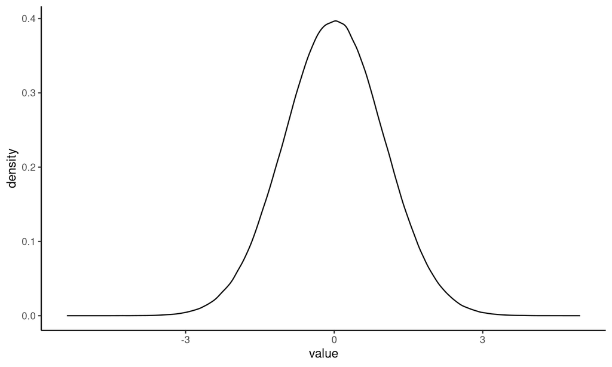

## 補論 統計的品質管理（つづき5）

### 分散分析

- 水準\(i\)が平均\(\mu\)に対して作用するか検討する手法。
- 局所管理するために、ブロック因子\(\rho_{j}\)も加味する
- 現代ならばPCに計算させるが、開始当初は計算尺や統計量表を活用。
- 問題を1つずつ切り分けて分析的に物事を考える方向へいざなう。

\[ y_{ij} \sim N(\mu+\alpha_{i}+\rho_{j}, \ \sigma^{2}) \]

## 補論 統計的品質管理(つづき6)

### 指標を使った表現

\[ C_{p}=\frac{S_{U}-S_{L}}{6s} \]

## 参考文献その2

- 門田安弘(2006)『トヨタプロダクションシステム』ダイヤモンド社
  - トヨタ生産方式と呼ばれるものに関する決定版
  - 小集団活動だけではなくいろいろなものを統合的に学ぶことができる
- 三中信宏（2015)『みなか先生といっしょに統計学の王国を歩いてみよう』羊土社
  - 初等統計学に関する素敵な解説書
  - 統計的品質管理に関する教科書もこのくらい平易ならよかったのに